# Project : Movielens Dataset Analysis

```python
import numpy as np
import pandas as pd
import matplotlib.pyplot as plt
get_ipython().run_line_magic('matplotlib', 'inline')
```

```python
from sklearn.metrics import *
from sklearn.model_selection import *
```

```python
from sklearn.metrics import confusion_matrix
from sklearn.metrics import accuracy_score
from sklearn.linear_model import LogisticRegression
from sklearn.tree import DecisionTreeClassifier
from sklearn.neighbors import KNeighborsClassifier
from sklearn.discriminant_analysis import LinearDiscriminantAnalysis
from sklearn.naive_bayes import GaussianNB
from sklearn.svm import SVC
```

1) Data acquisition of the movielens dataset • users dataset • rating dataset • movies dataset

```python
movie_data = pd.read_csv("D:\\Hash-Lab\\Movie-lens-case-study--main\\movies.dat",sep="::", header=None, names=['MovieID','Title','Genres'], encoding='latin-1' ,dtype={'MovieID': np.int32, 'Title': str, 'Genres': str}, engine='python')
users_data = pd.read_csv("D:\\Hash-Lab\\Movie-lens-case-study--main\\users.dat",sep="::", header=None, names=['UserID','Gender','Age','Occupation','Zip-code'], dtype={'UserID': np.int32, 'Gender': str, 'Age': np.int32, 'Occupation' : np.int32, 'Zip-code' : str}, engine='python')
ratings_data = pd.read_csv("D:\\Hash-Lab\\Movie-lens-case-study--main\\ratings.dat",sep="::", header=None, names=['UserID','MovieID','Rating','Timestamp'], dtype={'UserID': np.int32, 'MovieID': np.int32, 'Rating': int, 'Timestamp' : str}, engine='python')
```

2)Perform the Exploratory Data Analysis (EDA) for the users dataset • Visualize user age distribution • Visualize overall rating by users • Find and visualize the user rating of the movie “Toy Story” • Find and visualize the viewership of the movie “Toy Story” by age group • Find and visualize the top 25 movies by viewership rating • Find the rating for a particular user of user id = 2696 o Visualize the rating data by user of user id = 2696

```python
movie_data.head()
movie_data.shape
movie_data.isnull().sum()
movie_data.describe()
movie_data.info()


users_data.head()
users_data.shape
users_data.describe()
users_data.isnull().sum()
users_data.info()

ratings_data.head()
ratings_data.shape
ratings_data.describe()
ratings_data.info()
ratings_data.isnull().sum()
```

```
<class 'pandas.core.frame.DataFrame'>
RangeIndex: 3883 entries, 0 to 3882
Data columns (total 3 columns):
 #   Column   Non-Null Count  Dtype
---  ------   --------------  -----
 0   MovieID  3883 non-null   int32
 1   Title    3883 non-null   object
 2   Genres   3883 non-null   object
dtypes: int32(1), object(2)
memory usage: 76.0+ KB
<class 'pandas.core.frame.DataFrame'>
RangeIndex: 6040 entries, 0 to 6039
Data columns (total 5 columns):
 #   Column      Non-Null Count  Dtype
---  ------      --------------  -----
 0   UserID      6040 non-null   int32
 1   Gender      6040 non-null   object
 2   Age         6040 non-null   int32
 3   Occupation  6040 non-null   int32
 4   Zip-code    6040 non-null   object
dtypes: int32(3), object(2)
memory usage: 165.3+ KB
<class 'pandas.core.frame.DataFrame'>
RangeIndex: 1000209 entries, 0 to 1000208
Data columns (total 4 columns):
 #   Column     Non-Null Count    Dtype
---  ------     --------------    -----
 0   UserID     1000209 non-null  int32
 1   MovieID    1000209 non-null  int32
 2   Rating     1000209 non-null  int32
 3   Timestamp  1000209 non-null  object
dtypes: int32(3), object(1)
memory usage: 19.1+ MB
```

```
UserID       0
MovieID      0
Rating       0
Timestamp    0
dtype: int64
```

• Visualize user age distribution

```python
age_group = users_data.groupby('Age').size()
age_group
```

```
Age
1      222
18    1103
25    2096
35    1193
45     550
50     496
56     380
dtype: int64
```

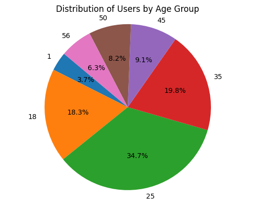

```python
plt.pie(age_group.values, labels=age_group.index, autopct='%1.1f%%', startangle=140)
plt.axis('equal')  # Equal aspect ratio ensures that pie is drawn as a circle
plt.title('Distribution of Users by Age Group')
plt.show()
```

• Visualize overall rating by users

```python
user_group = ratings_data.groupby(['UserID']).size()
user_group.head(10)
```

```
UserID
1      53
2     129
3      51
4      21
5     198
6      71
7      31
8     139
9     106
10    401
dtype: int64
```

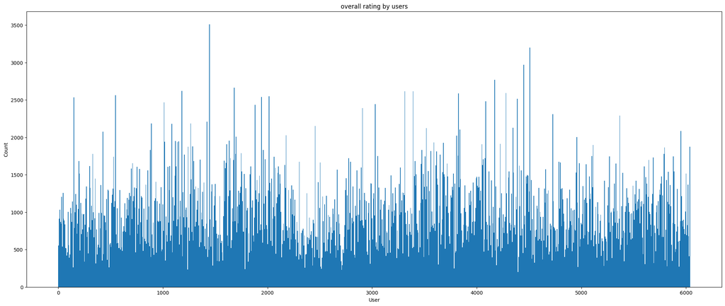

```python
plt.figure(figsize=(25,10))

plt.xlabel('User')
plt.ylabel('Count')
plt.title('overall rating by users')
plt.hist(x=[ratings_data.UserID], bins=1000)
plt.show()
```

• Visualize overall rating by gender

```python
gender_group = users_data.groupby('Gender').size()
gender_group
```

```
Gender
F    1709
M    4331
dtype: int64
```

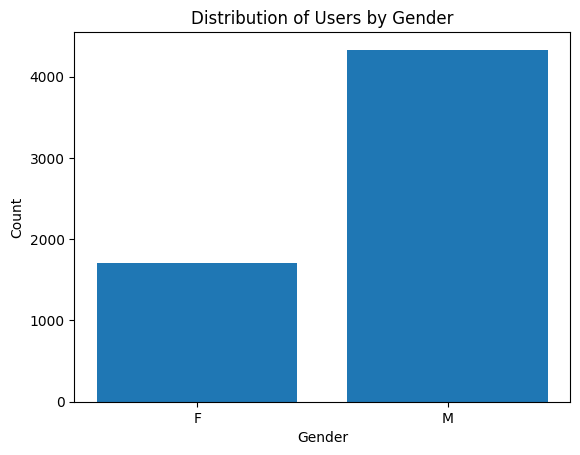

```python
# Plotting the histogram
plt.bar(gender_group.index, gender_group.values)

# Adding labels and title
plt.xlabel('Gender')
plt.ylabel('Count')
plt.title('Distribution of Users by Gender')

# Displaying the plot
plt.show()
```

• Find and visualize the user rating of the movie “Toy Story”

```python
toystory_data = ratings_data[ratings_data.MovieID==1]
toystory_data.head(10)
```

|  | UserID | MovieID | Rating | Timestamp |
| --- | --- | --- | --- | --- |
| 40 | 1 | 1 | 5 | 978824268 |
| 469 | 6 | 1 | 4 | 978237008 |
| 581 | 8 | 1 | 4 | 978233496 |
| 711 | 9 | 1 | 5 | 978225952 |
| 837 | 10 | 1 | 5 | 978226474 |
| 1966 | 18 | 1 | 4 | 978154768 |
| 2276 | 19 | 1 | 5 | 978555994 |
| 2530 | 21 | 1 | 3 | 978139347 |
| 2870 | 23 | 1 | 4 | 978463614 |
| 3405 | 26 | 1 | 3 | 978130703 |

```python
toystory_data.groupby('Rating').size()
```

```
Rating
1     16
2     61
3    345
4    835
5    820
dtype: int64
```

```python
toystory_data_group = toystory_data.groupby('Rating')
toystory_data_group.agg({'Rating':'mean'})
```

| Rating | Rating |
| --- | --- |
| 1 | 1.0 |
| 2 | 2.0 |
| 3 | 3.0 |
| 4 | 4.0 |
| 5 | 5.0 |

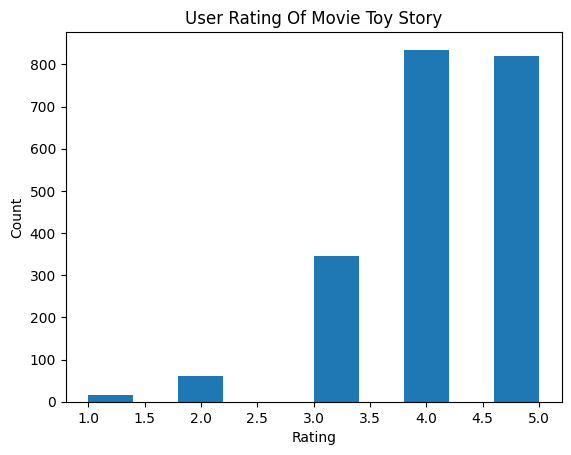

```python
plt.hist(x=toystory_data['Rating'])
plt.xlabel('Rating')
plt.ylabel('Count')
plt.title('User Rating Of Movie Toy Story')
plt.show()
```

• Find and visualize the viewership of the movie “Toy Story” by age group

```python
viewership = pd.merge(ratings_data, users_data, how='left', left_on=['UserID'], right_on=['UserID'])

viewership.shape
```

```
(1000209, 8)
```

```python
ratings_data.shape
```

```
(1000209, 4)
```

```python
viewership.head()
```

|  | UserID | MovieID | Rating | Timestamp | Gender | Age | Occupation | Zip-code |
| --- | --- | --- | --- | --- | --- | --- | --- | --- |
| 0 | 1 | 1193 | 5 | 978300760 | F | 1 | 10 | 48067 |
| 1 | 1 | 661 | 3 | 978302109 | F | 1 | 10 | 48067 |
| 2 | 1 | 914 | 3 | 978301968 | F | 1 | 10 | 48067 |
| 3 | 1 | 3408 | 4 | 978300275 | F | 1 | 10 | 48067 |
| 4 | 1 | 2355 | 5 | 978824291 | F | 1 | 10 | 48067 |

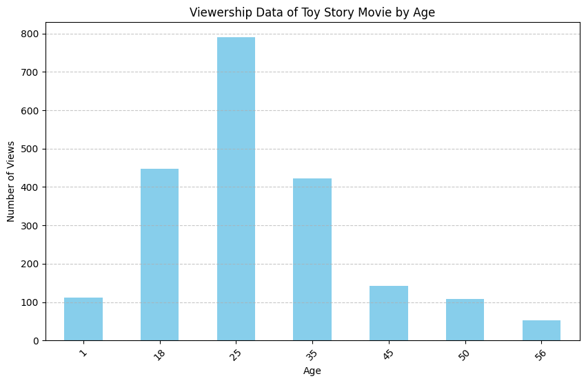

```python
viewership_of_toystory = viewership[viewership['MovieID'] == 1]

# Group viewership data by age and count the number of views
age_group = viewership_of_toystory.groupby('Age').size()

# Plotting the bar plot
plt.figure(figsize=(10, 6))
age_group.plot(kind='bar', color='skyblue')
plt.xlabel('Age')
plt.ylabel('Number of Views')
plt.title('Viewership Data of Toy Story Movie by Age')
plt.xticks(rotation=45)
plt.grid(axis='y', linestyle='--', alpha=0.7)
plt.show()
```

• Find and visualize the top 25 movies by viewership rating

```python
movie_rating = ratings_data.groupby(['MovieID'], as_index=False)
average_movie_ratings = movie_rating.agg({'Rating':'mean'})
top_25_movies = average_movie_ratings.sort_values('Rating', ascending=False).head(25)
top_25_movies
```

|  | MovieID | Rating |
| --- | --- | --- |
| 926 | 989 | 5.000000 |
| 3635 | 3881 | 5.000000 |
| 1652 | 1830 | 5.000000 |
| 3152 | 3382 | 5.000000 |
| 744 | 787 | 5.000000 |
| 3054 | 3280 | 5.000000 |
| 3367 | 3607 | 5.000000 |
| 3010 | 3233 | 5.000000 |
| 2955 | 3172 | 5.000000 |
| 3414 | 3656 | 5.000000 |
| 3021 | 3245 | 4.800000 |
| 51 | 53 | 4.750000 |
| 2309 | 2503 | 4.666667 |
| 2698 | 2905 | 4.608696 |
| 1839 | 2019 | 4.560510 |
| 309 | 318 | 4.554558 |
| 802 | 858 | 4.524966 |
| 708 | 745 | 4.520548 |
| 49 | 50 | 4.517106 |
| 513 | 527 | 4.510417 |
| 1066 | 1148 | 4.507937 |
| 2117 | 2309 | 4.500000 |
| 1626 | 1795 | 4.500000 |
| 2287 | 2480 | 4.500000 |
| 425 | 439 | 4.500000 |

```python
# Extracting MovieID and Rating from the top 25 movies DataFrame
movie_ids = top_25_movies['MovieID']
average_ratings = top_25_movies['Rating']
```

```python
pd.merge(top_25_movies, movie_data, how='left', left_on=['MovieID'], right_on=['MovieID'])
```

|  | MovieID | Rating | Title | Genres |
| --- | --- | --- | --- | --- |
| 0 | 989 | 5.000000 | Schlafes Bruder (Brother of Sleep) (1995) | Drama |
| 1 | 3881 | 5.000000 | Bittersweet Motel (2000) | Documentary |
| 2 | 1830 | 5.000000 | Follow the Bitch (1998) | Comedy |
| 3 | 3382 | 5.000000 | Song of Freedom (1936) | Drama |
| 4 | 787 | 5.000000 | Gate of Heavenly Peace, The (1995) | Documentary |
| 5 | 3280 | 5.000000 | Baby, The (1973) | Horror |
| 6 | 3607 | 5.000000 | One Little Indian (1973) | Comedy\|Drama\|Western |
| 7 | 3233 | 5.000000 | Smashing Time (1967) | Comedy |
| 8 | 3172 | 5.000000 | Ulysses (Ulisse) (1954) | Adventure |
| 9 | 3656 | 5.000000 | Lured (1947) | Crime |
| 10 | 3245 | 4.800000 | I Am Cuba (Soy Cuba/Ya Kuba) (1964) | Drama |
| 11 | 53 | 4.750000 | Lamerica (1994) | Drama |
| 12 | 2503 | 4.666667 | Apple, The (Sib) (1998) | Drama |
| 13 | 2905 | 4.608696 | Sanjuro (1962) | Action\|Adventure |
| 14 | 2019 | 4.560510 | Seven Samurai (The Magnificent Seven) (Shichin... | Action\|Drama |
| 15 | 318 | 4.554558 | Shawshank Redemption, The (1994) | Drama |
| 16 | 858 | 4.524966 | Godfather, The (1972) | Action\|Crime\|Drama |
| 17 | 745 | 4.520548 | Close Shave, A (1995) | Animation\|Comedy\|Thriller |
| 18 | 50 | 4.517106 | Usual Suspects, The (1995) | Crime\|Thriller |
| 19 | 527 | 4.510417 | Schindler's List (1993) | Drama\|War |
| 20 | 1148 | 4.507937 | Wrong Trousers, The (1993) | Animation\|Comedy |
| 21 | 2309 | 4.500000 | Inheritors, The (Die Siebtelbauern) (1998) | Drama |
| 22 | 1795 | 4.500000 | Callejón de los milagros, El (1995) | Drama |
| 23 | 2480 | 4.500000 | Dry Cleaning (Nettoyage à sec) (1997) | Drama |
| 24 | 439 | 4.500000 | Dangerous Game (1993) | Drama |

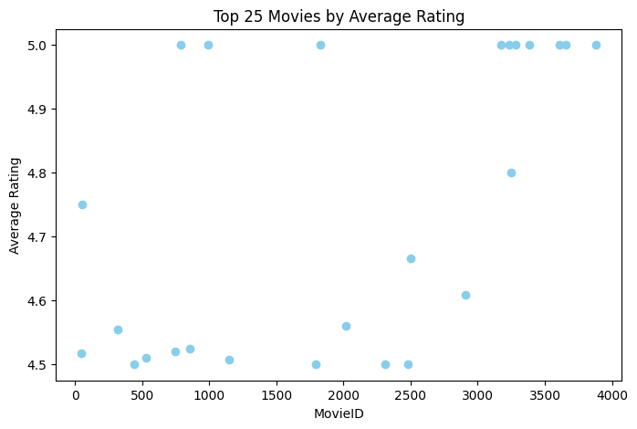

```python
# Scatter Plot
plt.figure(figsize=(8, 5))
plt.scatter(movie_ids, average_ratings, color='skyblue')
plt.xlabel('MovieID')
plt.ylabel('Average Rating')
plt.title('Top 25 Movies by Average Rating')
plt.show()
```

• Find the rating for a particular user of user id = 2696 o Visualize the rating data by user of user id = 2696

```python
user_rating_data = ratings_data[ratings_data['UserID']==2696]
user_rating_data.head()
```

|  | UserID | MovieID | Rating | Timestamp |
| --- | --- | --- | --- | --- |
| 440667 | 2696 | 1258 | 4 | 973308710 |
| 440668 | 2696 | 1270 | 2 | 973308676 |
| 440669 | 2696 | 1617 | 4 | 973308842 |
| 440670 | 2696 | 1625 | 4 | 973308842 |
| 440671 | 2696 | 1644 | 2 | 973308920 |

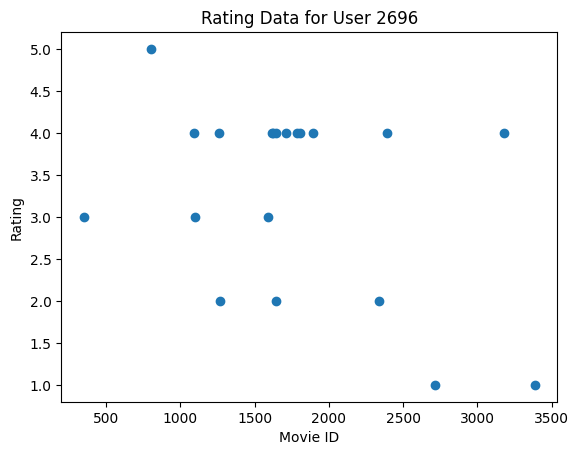

```python
plt.scatter(x=user_rating_data['MovieID'], y=user_rating_data['Rating'])
plt.xlabel('Movie ID')
plt.ylabel('Rating')
plt.title('Rating Data for User 2696')
plt.show()
```

Perform machine learning on first 500 extracted records • Use the following features: o movie id o age o occupation

```python
few_viewership = viewership.head(500)
few_viewership.shape

few_viewership.head()
```

|  | UserID | MovieID | Rating | Timestamp | Gender | Age | Occupation | Zip-code |
| --- | --- | --- | --- | --- | --- | --- | --- | --- |
| 0 | 1 | 1193 | 5 | 978300760 | F | 1 | 10 | 48067 |
| 1 | 1 | 661 | 3 | 978302109 | F | 1 | 10 | 48067 |
| 2 | 1 | 914 | 3 | 978301968 | F | 1 | 10 | 48067 |
| 3 | 1 | 3408 | 4 | 978300275 | F | 1 | 10 | 48067 |
| 4 | 1 | 2355 | 5 | 978824291 | F | 1 | 10 | 48067 |

```python
from sklearn.preprocessing import LabelEncoder
le = LabelEncoder()

le.fit(few_viewership['Age'])
x_age = le.transform(few_viewership['Age'])
x_age
```

```
array([0, 0, 0, 0, 0, 0, 0, 0, 0, 0, 0, 0, 0, 0, 0, 0, 0, 0, 0, 0, 0, 0,
       0, 0, 0, 0, 0, 0, 0, 0, 0, 0, 0, 0, 0, 0, 0, 0, 0, 0, 0, 0, 0, 0,
       0, 0, 0, 0, 0, 0, 0, 0, 0, 4, 4, 4, 4, 4, 4, 4, 4, 4, 4, 4, 4, 4,
       4, 4, 4, 4, 4, 4, 4, 4, 4, 4, 4, 4, 4, 4, 4, 4, 4, 4, 4, 4, 4, 4,
       4, 4, 4, 4, 4, 4, 4, 4, 4, 4, 4, 4, 4, 4, 4, 4, 4, 4, 4, 4, 4, 4,
       4, 4, 4, 4, 4, 4, 4, 4, 4, 4, 4, 4, 4, 4, 4, 4, 4, 4, 4, 4, 4, 4,
       4, 4, 4, 4, 4, 4, 4, 4, 4, 4, 4, 4, 4, 4, 4, 4, 4, 4, 4, 4, 4, 4,
       4, 4, 4, 4, 4, 4, 4, 4, 4, 4, 4, 4, 4, 4, 4, 4, 4, 4, 4, 4, 4, 4,
       4, 4, 4, 4, 4, 4, 1, 1, 1, 1, 1, 1, 1, 1, 1, 1, 1, 1, 1, 1, 1, 1,
       1, 1, 1, 1, 1, 1, 1, 1, 1, 1, 1, 1, 1, 1, 1, 1, 1, 1, 1, 1, 1, 1,
       1, 1, 1, 1, 1, 1, 1, 1, 1, 1, 1, 1, 1, 2, 2, 2, 2, 2, 2, 2, 2, 2,
       2, 2, 2, 2, 2, 2, 2, 2, 2, 2, 2, 2, 1, 1, 1, 1, 1, 1, 1, 1, 1, 1,
       1, 1, 1, 1, 1, 1, 1, 1, 1, 1, 1, 1, 1, 1, 1, 1, 1, 1, 1, 1, 1, 1,
       1, 1, 1, 1, 1, 1, 1, 1, 1, 1, 1, 1, 1, 1, 1, 1, 1, 1, 1, 1, 1, 1,
       1, 1, 1, 1, 1, 1, 1, 1, 1, 1, 1, 1, 1, 1, 1, 1, 1, 1, 1, 1, 1, 1,
       1, 1, 1, 1, 1, 1, 1, 1, 1, 1, 1, 1, 1, 1, 1, 1, 1, 1, 1, 1, 1, 1,
       1, 1, 1, 1, 1, 1, 1, 1, 1, 1, 1, 1, 1, 1, 1, 1, 1, 1, 1, 1, 1, 1,
       1, 1, 1, 1, 1, 1, 1, 1, 1, 1, 1, 1, 1, 1, 1, 1, 1, 1, 1, 1, 1, 1,
       1, 1, 1, 1, 1, 1, 1, 1, 1, 1, 1, 1, 1, 1, 1, 1, 1, 1, 1, 1, 1, 1,
       1, 1, 1, 1, 1, 1, 1, 1, 1, 1, 1, 1, 1, 1, 1, 1, 1, 1, 1, 1, 1, 1,
       1, 1, 1, 1, 1, 1, 1, 1, 1, 1, 1, 1, 3, 3, 3, 3, 3, 3, 3, 3, 3, 3,
       3, 3, 3, 3, 3, 3, 3, 3, 3, 3, 3, 3, 3, 3, 3, 3, 3, 3, 3, 3, 3, 3,
       3, 3, 3, 3, 3, 3, 3, 3, 3, 3, 3, 3, 3, 3, 3, 3], dtype=int64)
```

```python
le.fit(few_viewership['Occupation'])
x_occ = le.transform(few_viewership['Occupation'])
x_occ
```

```
array([2, 2, 2, 2, 2, 2, 2, 2, 2, 2, 2, 2, 2, 2, 2, 2, 2, 2, 2, 2, 2, 2,
       2, 2, 2, 2, 2, 2, 2, 2, 2, 2, 2, 2, 2, 2, 2, 2, 2, 2, 2, 2, 2, 2,
       2, 2, 2, 2, 2, 2, 2, 2, 2, 4, 4, 4, 4, 4, 4, 4, 4, 4, 4, 4, 4, 4,
       4, 4, 4, 4, 4, 4, 4, 4, 4, 4, 4, 4, 4, 4, 4, 4, 4, 4, 4, 4, 4, 4,
       4, 4, 4, 4, 4, 4, 4, 4, 4, 4, 4, 4, 4, 4, 4, 4, 4, 4, 4, 4, 4, 4,
       4, 4, 4, 4, 4, 4, 4, 4, 4, 4, 4, 4, 4, 4, 4, 4, 4, 4, 4, 4, 4, 4,
       4, 4, 4, 4, 4, 4, 4, 4, 4, 4, 4, 4, 4, 4, 4, 4, 4, 4, 4, 4, 4, 4,
       4, 4, 4, 4, 4, 4, 4, 4, 4, 4, 4, 4, 4, 4, 4, 4, 4, 4, 4, 4, 4, 4,
       4, 4, 4, 4, 4, 4, 3, 3, 3, 3, 3, 3, 3, 3, 3, 3, 3, 3, 3, 3, 3, 3,
       3, 3, 3, 3, 3, 3, 3, 3, 3, 3, 3, 3, 3, 3, 3, 3, 3, 3, 3, 3, 3, 3,
       3, 3, 3, 3, 3, 3, 3, 3, 3, 3, 3, 3, 3, 0, 0, 0, 0, 0, 0, 0, 0, 0,
       0, 0, 0, 0, 0, 0, 0, 0, 0, 0, 0, 0, 5, 5, 5, 5, 5, 5, 5, 5, 5, 5,
       5, 5, 5, 5, 5, 5, 5, 5, 5, 5, 5, 5, 5, 5, 5, 5, 5, 5, 5, 5, 5, 5,
       5, 5, 5, 5, 5, 5, 5, 5, 5, 5, 5, 5, 5, 5, 5, 5, 5, 5, 5, 5, 5, 5,
       5, 5, 5, 5, 5, 5, 5, 5, 5, 5, 5, 5, 5, 5, 5, 5, 5, 5, 5, 5, 5, 5,
       5, 5, 5, 5, 5, 5, 5, 5, 5, 5, 5, 5, 5, 5, 5, 5, 5, 5, 5, 5, 5, 5,
       5, 5, 5, 5, 5, 5, 5, 5, 5, 5, 5, 5, 5, 5, 5, 5, 5, 5, 5, 5, 5, 5,
       5, 5, 5, 5, 5, 5, 5, 5, 5, 5, 5, 5, 5, 5, 5, 5, 5, 5, 5, 5, 5, 5,
       5, 5, 5, 5, 5, 5, 5, 5, 5, 5, 5, 5, 5, 5, 5, 5, 5, 5, 5, 5, 5, 5,
       5, 5, 5, 5, 5, 5, 5, 5, 5, 5, 5, 5, 5, 5, 5, 5, 5, 5, 5, 5, 5, 5,
       5, 5, 5, 5, 5, 5, 5, 5, 5, 5, 5, 5, 1, 1, 1, 1, 1, 1, 1, 1, 1, 1,
       1, 1, 1, 1, 1, 1, 1, 1, 1, 1, 1, 1, 1, 1, 1, 1, 1, 1, 1, 1, 1, 1,
       1, 1, 1, 1, 1, 1, 1, 1, 1, 1, 1, 1, 1, 1, 1, 1], dtype=int64)
```

```python
le.fit(few_viewership['MovieID'])
x_movieid = le.transform(few_viewership['MovieID'])
x_movieid
```

```
array([130,  78,  95, 374, 280, 132, 156, 321,  71,  96,  72,  98, 287,
       330, 107, 318, 304, 251, 355, 319, 274,  80, 154,  61, 278,  12,
       119, 211, 186,  84, 271, 364, 189,  67, 231,  86, 226, 103, 316,
        18,   0, 243, 244, 305,  29, 104, 105, 135, 252,  62, 359,  74,
       145, 161, 346, 184,  75, 264,  76, 266, 302, 121, 329, 379, 136,
       222, 205, 137, 392, 326, 342, 139, 355,  49, 260, 356, 357, 343,
       148, 194,  33, 265, 347,  92,  44, 149, 360, 185, 158, 127, 366,
       367, 368,  17, 267, 293, 225, 380,  68, 207, 398, 323, 237, 100,
       227, 324, 140, 252,  60,  50, 272,  30, 170, 113, 403,  54, 173,
       255, 151, 162, 130, 224, 163, 279, 372, 289,  69, 131, 187,  83,
       133,  70, 281,  15, 308, 297, 234, 286, 407, 239, 193, 413, 240,
       241,  28, 122, 242,  20,   3,  21, 274, 115,  46, 294,  39,  51,
       118,  97,  52, 181, 376, 166, 378, 353,  85,  56, 312, 247, 244,
       220, 331, 248,  36, 135, 246, 400, 143,  41, 144, 145, 415, 146,
       377, 198,  76, 169, 389,  16, 314, 136, 172, 414, 112, 338, 195,
```

[output cut: 24 more lines]

```python
few_viewership['New Age'] = x_age
few_viewership['New Occupation'] = x_occ
few_viewership['New MovieID'] = x_movieid
```

```python
x_input = few_viewership[['New Age','New Occupation','New MovieID']]
y_target = few_viewership['Rating']

x_input.head()
```

|  | New Age | New Occupation | New MovieID |
| --- | --- | --- | --- |
| 0 | 0 | 2 | 130 |
| 1 | 0 | 2 | 78 |
| 2 | 0 | 2 | 95 |
| 3 | 0 | 2 | 374 |
| 4 | 0 | 2 | 280 |

```python
x_train, x_test, y_train, y_test = train_test_split(x_input, y_target, test_size=0.25)

x_train.shape, x_test.shape, y_train.shape, y_test.shape
```

```
((375, 3), (125, 3), (375,), (125,))
```

```python
from sklearn.linear_model import LogisticRegression
logitReg = LogisticRegression()
lm = logitReg.fit(x_train, y_train)

result = logitReg.predict(x_test)

result
```

```
array([4, 4, 4, 3, 4, 3, 4, 3, 4, 3, 4, 4, 4, 3, 4, 3, 4, 4, 4, 4, 4, 3,
       4, 4, 3, 4, 3, 4, 4, 4, 4, 4, 5, 4, 4, 4, 4, 3, 4, 4, 4, 4, 4, 4,
       4, 3, 4, 3, 4, 4, 4, 4, 4, 4, 4, 4, 4, 3, 3, 4, 3, 4, 3, 3, 3, 3,
       3, 4, 3, 4, 5, 4, 4, 3, 5, 3, 3, 3, 4, 3, 4, 3, 4, 4, 5, 4, 4, 4,
       3, 4, 4, 3, 4, 4, 3, 3, 3, 3, 4, 5, 4, 3, 4, 4, 3, 4, 4, 4, 3, 3,
       4, 5, 4, 4, 4, 3, 4, 3, 3, 5, 4, 3, 4, 5, 3])
```

```python
estimated = pd.Series(result, name='Estimated Values')

final_result = pd.concat([y_test, estimated], axis=1)
```

```python
print (accuracy_score(y_test, result))
```

```
0.304
```

```python
print (confusion_matrix(y_test, result))
```

```
[[ 0  0  2  7  0]
 [ 0  0  7  9  0]
 [ 0  0 14 16  0]
 [ 0  0 11 24  8]
 [ 0  0  8 19  0]]
```

```python
print (classification_report(y_test, result, zero_division=0))
```

```
              precision    recall  f1-score   support

           1       0.00      0.00      0.00         9
           2       0.00      0.00      0.00        16
           3       0.33      0.47      0.39        30
           4       0.32      0.56      0.41        43
           5       0.00      0.00      0.00        27

    accuracy                           0.30       125
   macro avg       0.13      0.20      0.16       125
weighted avg       0.19      0.30      0.23       125
```